# Project Business Statistics: E-news Express

**Marks: 60**

## Define Problem Statement and Objectives

The main issue to be addressed is identifying the reason for the decline in new monthly subscribers compared to the previous year. It is believed that the current webpage design may be the cause.

To accomplish our goals, we have the following objectives:

Investigate if users spend more time on the new landing page compared to the existing landing page. Determine whether the conversion rate of the new page is higher than that of the old page. Examine the relationship between the preferred language of the users and their converted status. Determine if there is any variation in the time spent on the new page for users of different preferred languages.

## Import all the necessary libraries

```python
#Libraries to help with reading and manipulating data
import numpy as np
import pandas as pd

#Libraries to help with data visualization
import matplotlib.pyplot as plt
import seaborn as sns
%matplotlib inline

#Libraries to help with statistical analysis
import scipy.stats as stats
```

## Reading the Data into a DataFrame

```python
abtest = pd.read_csv ("6821970-abtest.csv") #reading the dataset
```

## Explore the dataset and extract insights using Exploratory Data Analysis

- Data Overview
  - Viewing the first and last few rows of the dataset
  - Checking the shape of the dataset
  - Getting the statistical summary for the variables
- Check for missing values
- Check for duplicates

```python
abtest.head() #shows the first five rows of the dataset
```

|  | user_id | group | landing_page | time_spent_on_the_page | converted | language_preferred |
| --- | --- | --- | --- | --- | --- | --- |
| 0 | 546592 | control | old | 3.48 | no | Spanish |
| 1 | 546468 | treatment | new | 7.13 | yes | English |
| 2 | 546462 | treatment | new | 4.40 | no | Spanish |
| 3 | 546567 | control | old | 3.02 | no | French |
| 4 | 546459 | treatment | new | 4.75 | yes | Spanish |

```python
 abtest.tail() #shows the last five rows of the dataset
```

|  | user_id | group | landing_page | time_spent_on_the_page | converted | language_preferred |
| --- | --- | --- | --- | --- | --- | --- |
| 95 | 546446 | treatment | new | 5.15 | no | Spanish |
| 96 | 546544 | control | old | 6.52 | yes | English |
| 97 | 546472 | treatment | new | 7.07 | yes | Spanish |
| 98 | 546481 | treatment | new | 6.20 | yes | Spanish |
| 99 | 546483 | treatment | new | 5.86 | yes | English |

```python
abtest.shape # shows the rows and columns of the dataset
```

```
(100, 6)
```

```python
abtest.isna().sum() # check for missing data in the dataset
```

```
user_id                   0
group                     0
landing_page              0
time_spent_on_the_page    0
converted                 0
language_preferred        0
dtype: int64
```

```python
abtest.duplicated().sum() # check for duplicates in the data set
```

```
0
```

```python
abtest.info() #showing attributes of different types in the data
```

```
<class 'pandas.core.frame.DataFrame'>
RangeIndex: 100 entries, 0 to 99
Data columns (total 6 columns):
 #   Column                  Non-Null Count  Dtype
---  ------                  --------------  -----
 0   user_id                 100 non-null    int64
 1   group                   100 non-null    object
 2   landing_page            100 non-null    object
 3   time_spent_on_the_page  100 non-null    float64
 4   converted               100 non-null    object
 5   language_preferred      100 non-null    object
dtypes: float64(1), int64(1), object(4)
memory usage: 4.8+ KB
```

```python
abtest.describe(include='all').T
```

|  | count | unique | top | freq | mean | std | min | 25% | 50% | 75% | max |
| --- | --- | --- | --- | --- | --- | --- | --- | --- | --- | --- | --- |
| user_id | 100.0 | NaN | NaN | NaN | 546517.0 | 52.295779 | 546443.0 | 546467.75 | 546492.5 | 546567.25 | 546592.0 |
| group | 100 | 2 | control | 50 | NaN | NaN | NaN | NaN | NaN | NaN | NaN |
| landing_page | 100 | 2 | old | 50 | NaN | NaN | NaN | NaN | NaN | NaN | NaN |
| time_spent_on_the_page | 100.0 | NaN | NaN | NaN | 5.3778 | 2.378166 | 0.19 | 3.88 | 5.415 | 7.0225 | 10.71 |
| converted | 100 | 2 | yes | 54 | NaN | NaN | NaN | NaN | NaN | NaN | NaN |
| language_preferred | 100 | 3 | Spanish | 34 | NaN | NaN | NaN | NaN | NaN | NaN | NaN |

```python
abtest['group'].unique()
```

```
array(['control', 'treatment'], dtype=object)
```

```python
abtest['user_id'].unique()
```

```
array([546592, 546468, 546462, 546567, 546459, 546558, 546448, 546581,
       546461, 546548, 546588, 546546, 546491, 546478, 546578, 546466,
       546443, 546555, 546493, 546549, 546560, 546584, 546450, 546475,
       546456, 546455, 546469, 546586, 546471, 546575, 546464, 546556,
       546585, 546577, 546587, 546552, 546551, 546557, 546487, 546589,
       546559, 546570, 546489, 546453, 546488, 546565, 546460, 546458,
       546492, 546473, 546554, 546457, 546479, 546576, 546482, 546563,
       546569, 546454, 546562, 546574, 546470, 546467, 546572, 546590,
       546553, 546445, 546545, 546582, 546484, 546579, 546568, 546476,
       546452, 546444, 546591, 546583, 546573, 546485, 546486, 546547,
       546490, 546449, 546463, 546580, 546571, 546564, 546465, 546480,
       546447, 546561, 546477, 546451, 546566, 546474, 546550, 546446,
       546544, 546472, 546481, 546483])
```

```python
abtest['landing_page'].unique()
```

```
array(['old', 'new'], dtype=object)
```

```python
abtest['landing_page'].value_counts()
```

```
old    50
new    50
Name: landing_page, dtype: int64
```

```python
abtest['language_preferred'].unique() # to check the number of unique Data add letter 'n' in front of .unique() function
```

```
array(['Spanish', 'English', 'French'], dtype=object)
```

```python
abtest['language_preferred'].value_counts()
```

```
Spanish    34
French     34
English    32
Name: language_preferred, dtype: int64
```

### Univariate Analysis

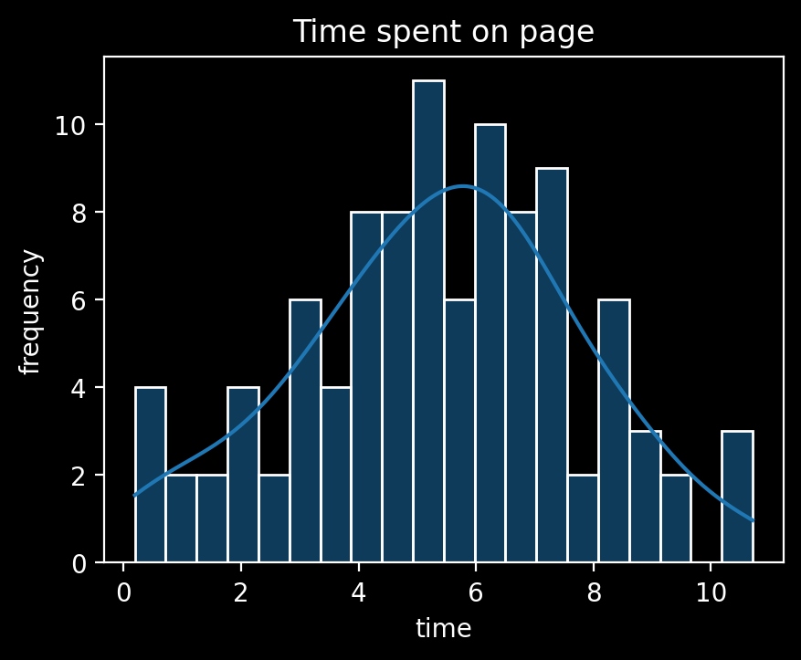

```python
plt.title('Time spent on page')
plt.xlabel('time')
plt.ylabel('frequency')
sns.histplot(data=abtest, x='time_spent_on_the_page', bins=20, kde= True);
```

The distribution is normally distributed.

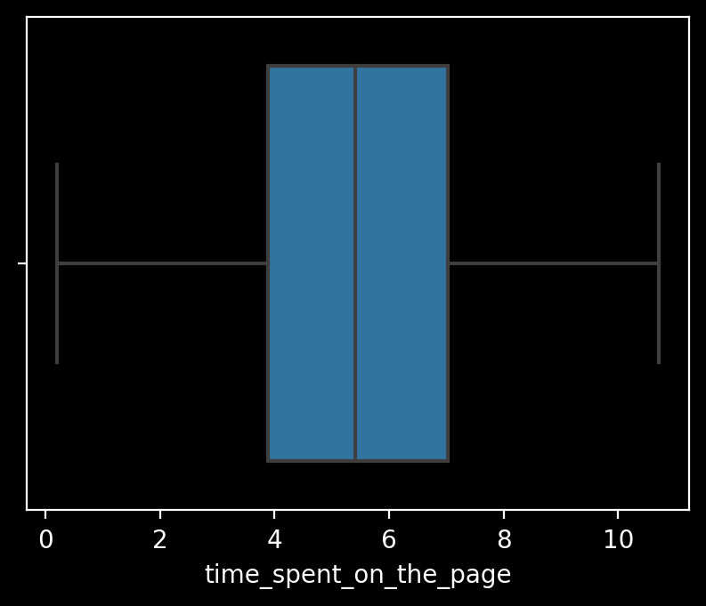

```python
sns.boxplot(data=abtest, x='time_spent_on_the_page')
```

[figure not shown]

```python
plt.title('group')
plt.xlabel('time')
plt.ylabel('frequency')
sns.countplot(data=abtest, x='group',);
```

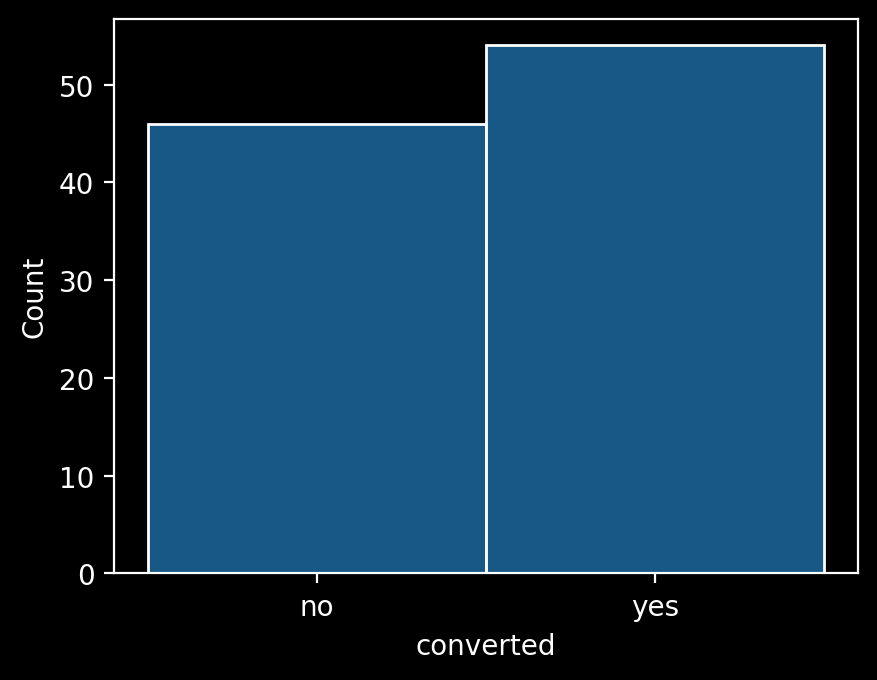

```python
sns.histplot(data=abtest, x='converted');
```

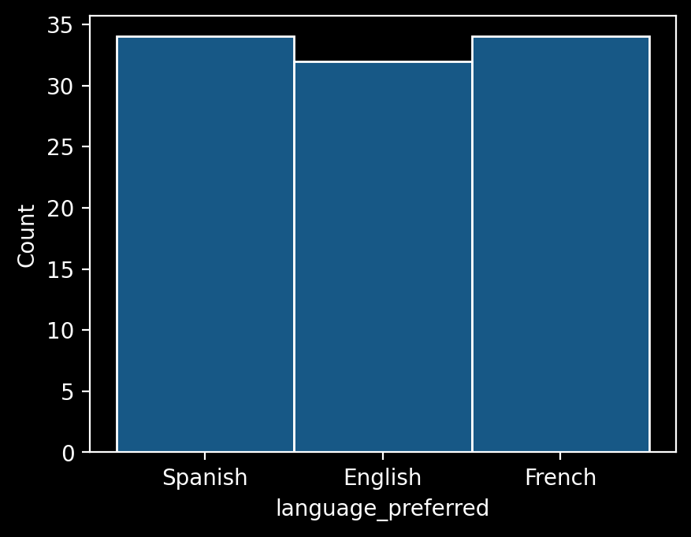

```python
sns.histplot(data=abtest, x='language_preferred');
```

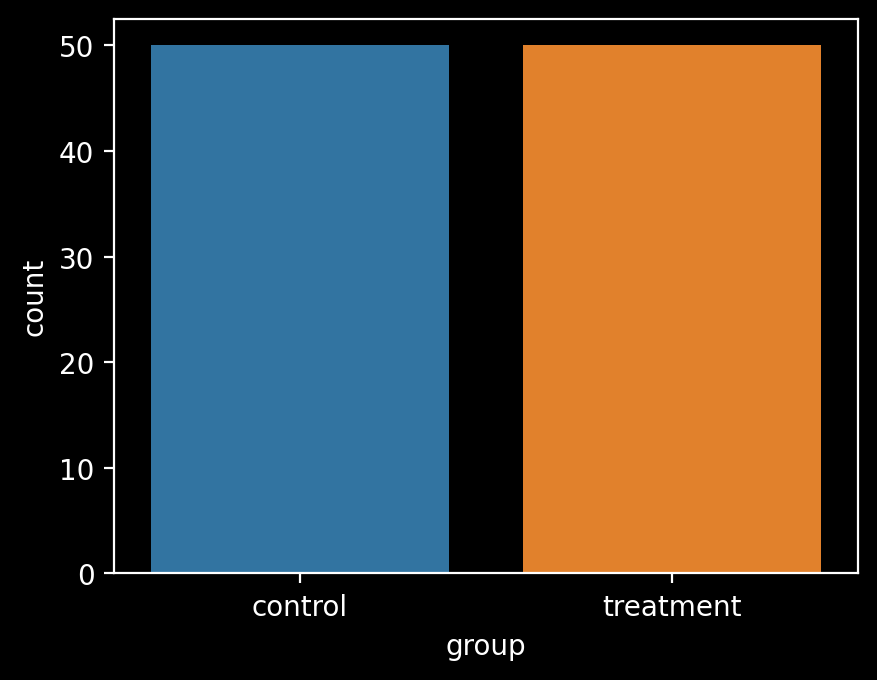

```python
sns.countplot(data=abtest, x='group');
```

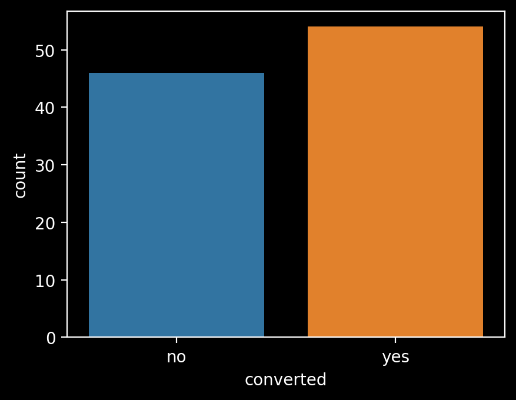

```python
sns.countplot(data=abtest, x='converted');
```

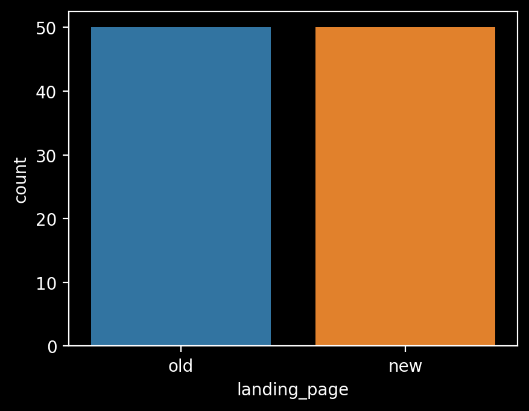

```python
sns.countplot(data=abtest, x='landing_page');
```

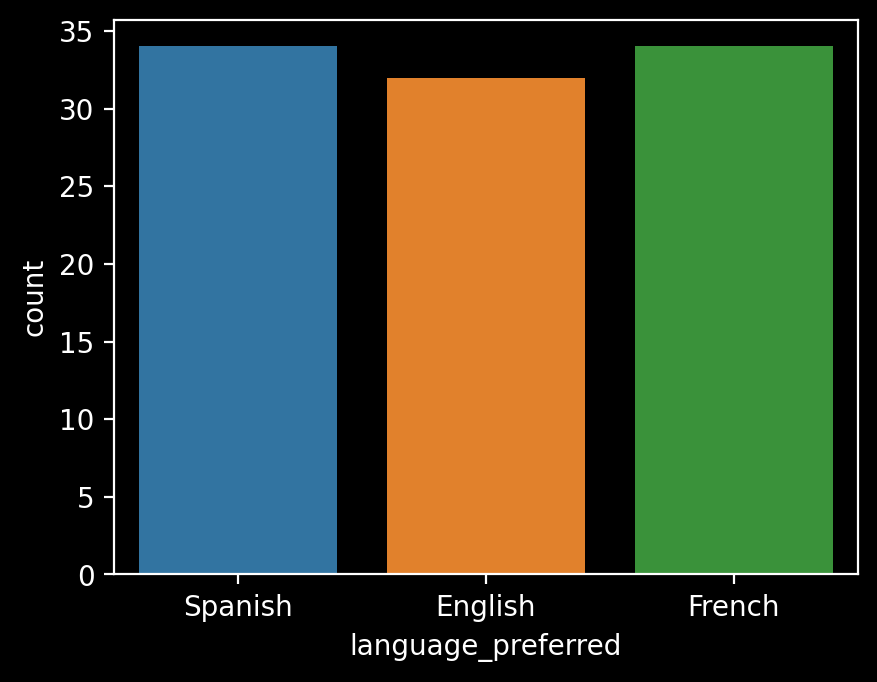

```python
sns.countplot(data=abtest, x='language_preferred')
```

### Bivariate Analysis

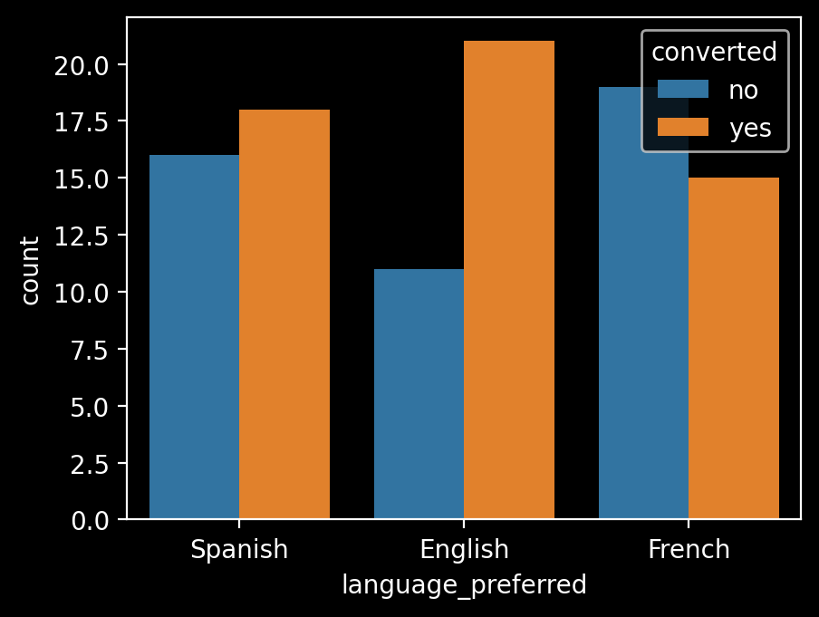

```python
sns.countplot(data=abtest, x='language_preferred', hue='converted');
```

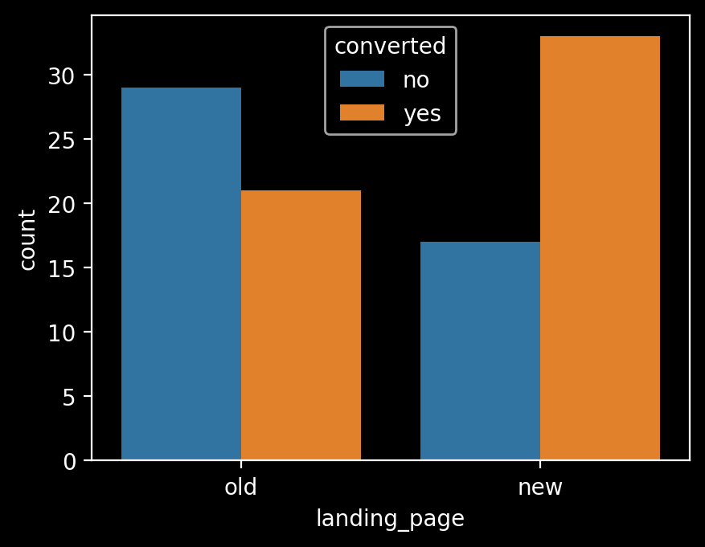

```python
sns.countplot(data=abtest, x='landing_page', hue='converted')
```

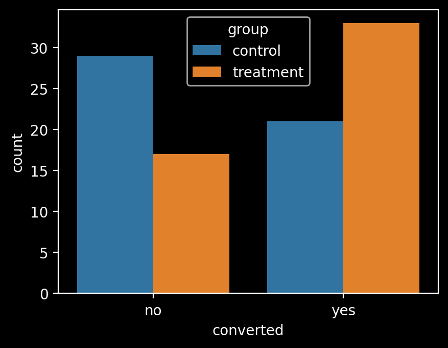

```python
sns.countplot(data=abtest, x='converted', hue='group')
```

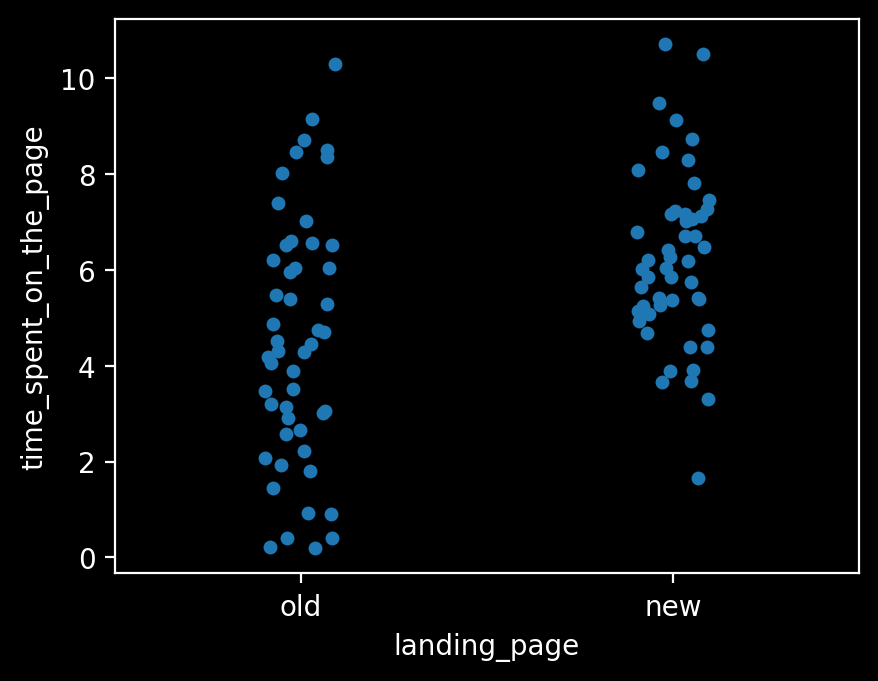

```python
sns.stripplot(data=abtest, x='landing_page', y='time_spent_on_the_page')
```

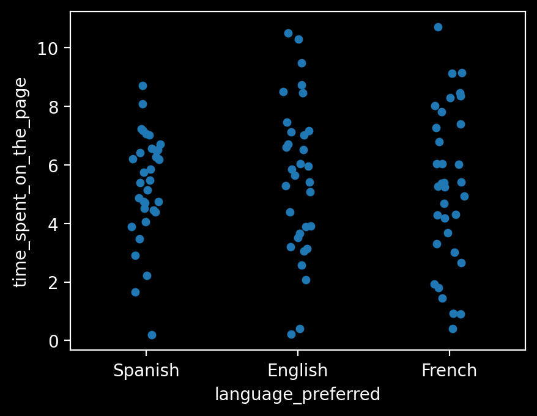

```python
sns.stripplot(data=abtest, x='language_preferred', y='time_spent_on_the_page')
```

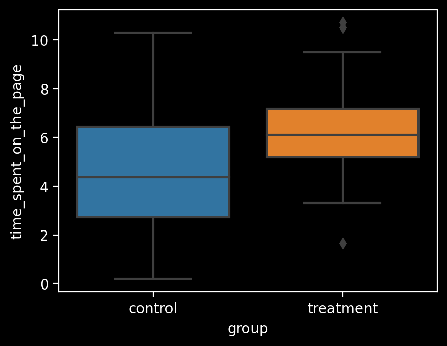

```python
sns.boxplot(data=abtest, x='group', y='time_spent_on_the_page')
```

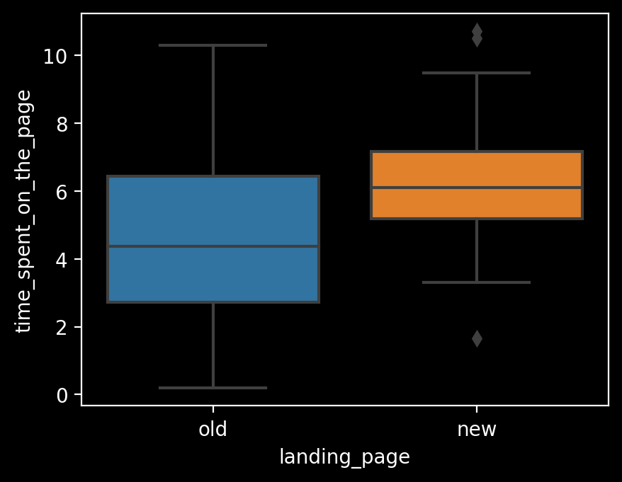

```python
sns.boxplot(data=abtest, x='landing_page', y='time_spent_on_the_page')
```

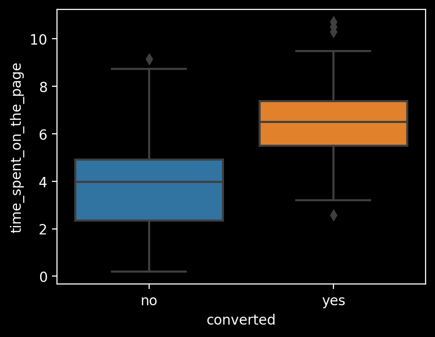

```python
sns.boxplot(data=abtest, x='converted', y='time_spent_on_the_page')
```

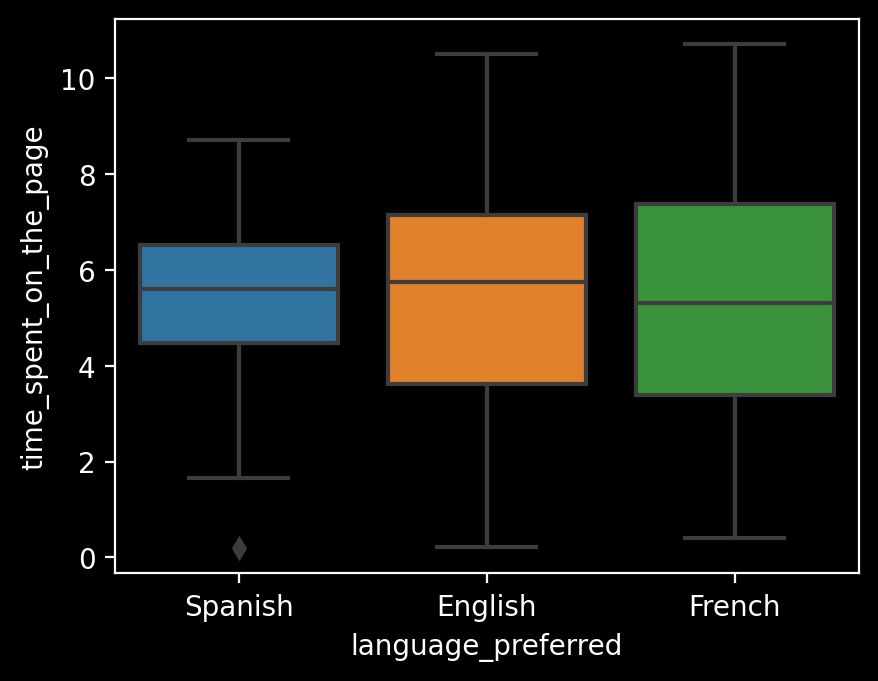

```python
sns.boxplot(data=abtest, x='language_preferred', y='time_spent_on_the_page')
```

## 1. Do the users spend more time on the new landing page than the existing landing page?

### Perform Visual Analysis

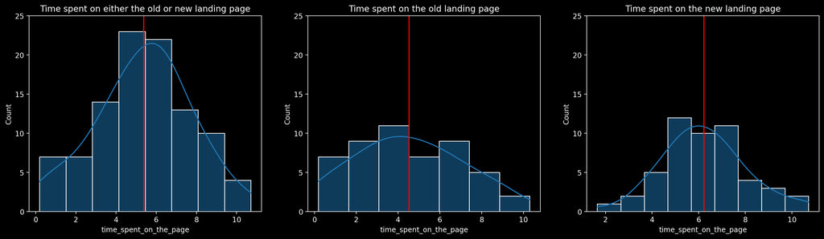

```
Total & average time spent on the existing landing page across 50 users (control group):  226.62 mins and 4.53 mins.
Total & average time spent on the new landing page across 50 users (treatment group):  311.16 mins and 6.22 mins.
```

```python
fig, abt = plt.subplots(1, 3, figsize=(20,5))

sns.histplot(abtest["time_spent_on_the_page"], ax=abt[0], kde=True) #Using seaborn library to plot the distribution of time spent on the page
abt[0].set_ylim((0,25)) #formattin the y axis to 0 - 25
abt[0].axvline(abtest["time_spent_on_the_page"].mean(), c="r")
abt[0].set_title("Time spent on either the old or new landing page")

abtest_old = abtest[abtest["landing_page"] == "old"]
sns.histplot(abtest_old["time_spent_on_the_page"], ax=abt[1], kde=True)
abt[1].set_ylim((0,25))
abt[1].axvline(abtest_old["time_spent_on_the_page"].mean(), c="r")
abt[1].set_title("Time spent on the old landing page")

abtest_new = abtest[abtest["landing_page"] == "new"]
sns.histplot(abtest_new["time_spent_on_the_page"], ax=abt[2], kde=True)
abt[2].set_ylim((0,25))
abt[2].axvline(abtest_new["time_spent_on_the_page"].mean(), c="r")
abt[2].set_title("Time spent on the new landing page")

plt.show()

print("Total & average time spent on the existing landing page across 50 users (control group): ",
      str(round(abtest_old["time_spent_on_the_page"].sum(), 2)) + " mins and",
      str(round(abtest_old["time_spent_on_the_page"].mean(), 2)) + " mins.")

print("Total & average time spent on the new landing page across 50 users (treatment group): ",
      str(round(abtest_new["time_spent_on_the_page"].sum(), 2)) + " mins and",
      str(round(abtest_new["time_spent_on_the_page"].mean(), 2)) + " mins.")
```

### Step 1: Define the null and alternate hypotheses

The null and alternative hypothesis can be formulated as:

$H_0$ : The mean time spent on the new landing page is the same as the mean time spent on the old landing page

$H_1$ : The mean time spent on the new landing page is higher than the mean time spent on the old landing page

Let new landing page and exist'ing page be $\mu_1, \mu_2$ respectively. Mathematically, the above formulated hypothesis can be written as:

$H_0:\mu_1 = \mu_2$

against the alternate hypothesis

$H_1:\mu_1>\mu_2$

### Step 2: Select Appropriate test

Based on the above information, we select a Two Sample Independent T-test for Equality of Means with Unequal Standard Deviation

### Step 4: Collect and prepare data

```python
μ_1, μ_2 = abtest_new["time_spent_on_the_page"].mean() , abtest_old["time_spent_on_the_page"].mean()
std1, std2 = abtest_new["time_spent_on_the_page"].std() , abtest_old["time_spent_on_the_page"].std()
print("μ_1, μ_2, std1, std2:", str(round(μ_1,2))+",", str(round(μ_2,2))+",", str(round(std1,2))+","\
      , str(round(std2,2))+".")
```

```
μ_1, μ_2, std1, std2: 6.22, 4.53, 1.82, 2.58.
```

### Step 5: Calculate the p-value

```python
from scipy.stats import ttest_ind

#finding the p-value
test_stat, p_value = ttest_ind(abtest_new["time_spent_on_the_page"], abtest_old["time_spent_on_the_page"], \
                               equal_var = False, alternative = 'greater')
print('The p-value is ', p_value)
```

```
The p-value is  0.0001392381225166549
```

### Step 6: Compare the p-value with $\alpha$

```python
print('The p-value is ', p_value, 'and the significance level alpha is 0.05')
```

```
The p-value is  0.0001392381225166549 and the significance level alpha is 0.05
```

### Step 7: Draw inference

Since the p-value (0.00014) is less than the significance level, we can reject the null hypothesis. Hence, we do have enough evidence to support the claim that the mean time spent on the new landing page is higher tha mean time spent on the old landing page

**A similar approach can be followed to answer the other questions.**

## 2. Is the conversion rate (the proportion of users who visit the landing page and get converted) for the new page greater than the conversion rate for the old page?

## Perform Visual Analysis

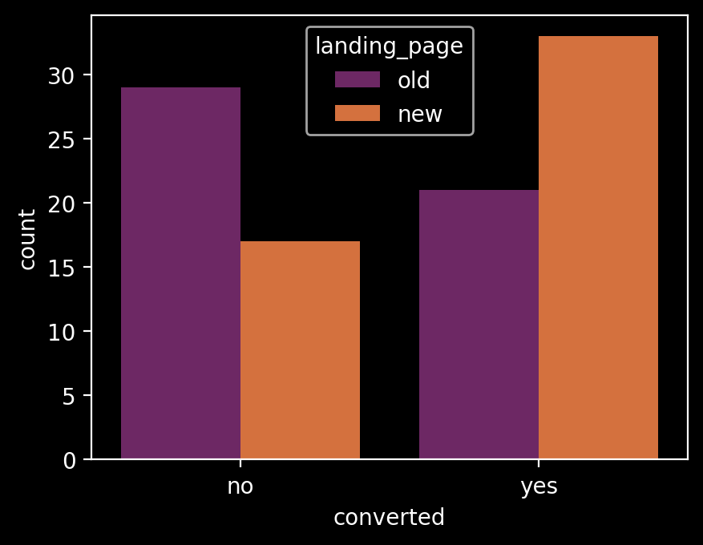

```
% converted - old landing page:  42.0%
% converted - new landing page:  66.0%
```

```python
sns.countplot(x="converted", data=abtest, hue="landing_page", palette = 'inferno');
plt.show()

print('% converted - old landing page: ', \
      str((abtest_old[abtest_old['converted']=='yes'].count()['group']/50)*100)+ '%' )

print('% converted - new landing page: ', \
      str((abtest_new[abtest_new['converted']=='yes'].count()['group']/50)*100)+ '%')
```

## Step 1: Define the null and alternate hypotheses

The null and alternative hypothesis can be formulated as:

$H_0$ : The conversion rate for the new landing page is the same as the conversion rate for the existing page

$H_1$ : The conversion rate for the new landing page is greater than the conversion rate for the existing page

Let new landing page and existing page be c_1, c_2 respectively. Mathematically, the above formulated hypothesis can be written as:

H0 : c_1 = c_2

Ha : c_1 > c_2

## Step 2: Select Appropriate test

To test the proportions, a Two Proportion Z-test is selected.

## Step 3: Decide the significance level

The significance level set is at 0.05

## Step 4: Collect and prepare data

```python
convert_new = float(abtest_new[abtest["converted"]=="yes"].count()["group"])
c_1 = float(round(convert_new/50, 2))
convert_old = float(abtest_old[abtest["converted"]=="yes"].count()["group"])
c_2 = float(round(convert_old/50, 2))

print('The conversion rates for the new and old landing pages are', c_1, 'and', c_2, 'respectively.')
```

```
The conversion rates for the new and old landing pages are 0.66 and 0.42 respectively.
```

## Step 5: Calculate the p-value

```python
from statsmodels.stats.proportion import proportions_ztest
stat, pval = proportions_ztest([convert_new, convert_old], [50,50], alternative = 'larger')

print('The p-value is ', str(pval),)
```

```
The p-value is  0.008026308204056278
```

## Step 6: Compare the p-value with $\alpha$

```python
print('The p-value is ', str(pval), 'and the significance level alpha is 0.05')
```

```
The p-value is  0.008026308204056278 and the significance level alpha is 0.05
```

## Step 7: Draw inference

Since the p-value (p=0.008) is less than the significance level of 0.05, we can reject the null hypothesis. Hence, we have enough evidence to support the claim that the conversion rate for the new landing page is higher than the conversion rate for the old landing page.

## 3. Is the conversion and preferred language are independent or related?

## Perform Visuailisation Analysis

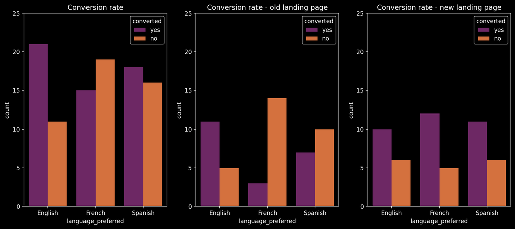

```
Number of users that prefer English, French and Spanish in the dataset are 32, 34, and 34.

% change in converted - new landing page vs old landing page:
language_preferred
English   -10.00
French     75.00
Spanish    36.36
Name: user_id, dtype: float64
```

```python
fig,ax = plt.subplots(1,3, figsize=(15,6))

sns.countplot(x="language_preferred", data=abtest.sort_values("language_preferred", ascending = True), \
              hue="converted", palette = 'inferno', ax=ax[0]);
ax[0].set_ylim((0,25))
ax[0].set_title("Conversion rate")

sns.countplot(x="language_preferred", data=abtest_old.sort_values("language_preferred", ascending = True), \
              hue="converted", palette = 'inferno', ax=ax[1]);
ax[1].set_ylim((0,25))
ax[1].set_title("Conversion rate - old landing page")

sns.countplot(x="language_preferred", data=abtest_new.sort_values("language_preferred", ascending = True), \
              hue="converted", palette = 'inferno', ax=ax[2]);
ax[2].set_ylim((0,25))
ax[2].set_title("Conversion rate - new landing page")

plt.show()

print("Number of users that prefer English, French and Spanish in the dataset are",  \
      str(abtest.groupby("language_preferred").count()["user_id"]["English"])+",", \
      str(abtest.groupby("language_preferred").count()["user_id"]["French"])+", and", \
      str(abtest.groupby("language_preferred").count()["user_id"]["Spanish"])+"." +"\n")

converted_new = abtest_new[abtest["converted"]=="yes"]
converted_old = abtest_old[abtest["converted"]=="yes"]

print("% change in converted - new landing page vs old landing page:")

print(round(100*(converted_new.groupby("language_preferred").count()["user_id"] \
    - converted_old.groupby("language_preferred").count()["user_id"])/converted_new.groupby \
("language_preferred").count()["user_id"], 2))
```

## Step 2: Select Appropriate test

## Step 3: Decide the significance level

The significance level set is at 0.05

## Step 4: Collect and prepare data

```python
Convert_language = pd.crosstab(abtest.converted, abtest.language_preferred).rename_axis(None,axis=1).reset_index()
Convert_language
```

|  | converted | English | French | Spanish |
| --- | --- | --- | --- | --- |
| 0 | no | 11 | 19 | 16 |
| 1 | yes | 21 | 15 | 18 |

## Step 5: Calculate the p-value

```python
from scipy.stats import chi2_contingency

#finding the p-value
chi, p_value, dof, expected = chi2_contingency(Convert_language.drop('converted', axis = 1))
p_value
```

```
0.21298887487543447
```

## Step 6: Compare the p-value with $\alpha$

```python
print('The p-value is ', p_value, 'and we set the significance level to 0.05')
```

```
The p-value is  0.21298887487543447 and we set the significance level to 0.05
```

## Step 7: Draw inference

Since the p-value (p=0.21) is greater than the significance level of 0.05, we cannot reject the null hypothesis. Therefore, we do not have sufficient evidence to support the claim that the conversion rate depends on the preferred language.

## 4. Is the time spent on the new page same for the different language users?

## Perform visual analysis

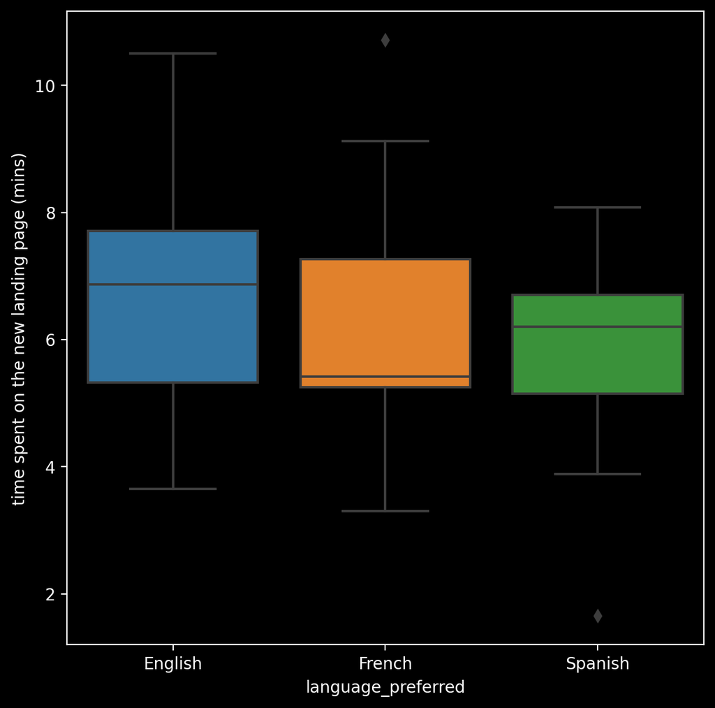

```python
plt.figure(figsize=(7,7))
sns.boxplot(x="language_preferred", y="time_spent_on_the_page",\
            data=abtest_new.sort_values("language_preferred", ascending = True));
plt.ylabel("time spent on the new landing page (mins)")
plt.show()
```

## Step 1: Define the null and alternate hypotheses

Let μ_1, μ_2, μ_3 be the mean time spent on the new landing page for the different language users - English, French and Spanish respectively.

$\H_0$ : Null Hypothesis - The time spent on the new landing page is the same for all languages μ1 = μ2 = μ3

$\H_a $: At least one of μ1, μ2, μ3 is different from the rest

## Step 2: Select Appropriate test

The analysis involves testing the means of multiple groups, and therefore, we selected the Analysis of Variance (ANOVA) test.

## Step 3: Decide the significance level

The significance level set is at 0.05

## Step 4: Collect and prepare data

The next step is to check the normality and equality of variance assumptions. To test for normality, we will use the Shapiro-Wilk test. For the equality of variance, we will use Levene's test.

Specifically, for the Shapiro-Wilk test:

$\H_0$: Time spent on the new landing page follows a normal distribution

$\H_a$: Time spent on the new landing page does not follow a normal distribution

```python
# finding the p-value
w, p_value = stats.shapiro(abtest_new['time_spent_on_the_page'])
print('The p-value is', p_value)
```

```
The p-value is 0.8040016293525696
```

As the p-value is greater than the significance level, we do not have enough evidence to reject the null hypothesis that the time spent on the new landing page follows a normal distribution.

### Levene's Test

```python
H0:Null Hypothesis - All population variances (time spent on new landing page for different preferred languages) are equal.
Ha:Alternate Hypothesis - Atleast one variance is different from the rest.
```

```python
from scipy.stats import levene
statistic, p_value = levene( abtest_new['time_spent_on_the_page'][abtest_new['language_preferred']=="English"],
                             abtest_new['time_spent_on_the_page'][abtest_new['language_preferred']=="French"],
                             abtest_new['time_spent_on_the_page'][abtest_new['language_preferred']=="Spanish"])
# find the p-value
print('The p-value is', p_value)
```

```
The p-value is 0.46711357711340173
```

Since the p-value is greater than the significance level, we do not have enough evidence to reject the null hypothesis that all population variances are equal.

## Step 5: Calculate the p-value

```python
from scipy.stats import f_oneway

# perform one-way anova test
test_stat, p_value = f_oneway(abtest_new.loc[abtest_new['language_preferred'] == 'English', 'time_spent_on_the_page'],
                              abtest_new.loc[abtest_new['language_preferred'] == 'French', 'time_spent_on_the_page'],
                              abtest_new.loc[abtest_new['language_preferred'] == 'Spanish', 'time_spent_on_the_page'])
print('The p-value is ' + str(p_value))
```

```
The p-value is 0.43204138694325955
```

## Step 6: Compare the p-value with $\alpha$

```python
print('The p-value is ', p_value, 'and the significance level alpha is 0.05')
```

```
The p-value is  0.43204138694325955 and the significance level alpha is 0.05
```

## Step 7: Draw inference

Since the p-value is much larger than the significance level, we do not have enough evidence to reject the null hypothesis. Therefore, we cannot conclude that at least one mean time spent on the new landing page for the three preferred languages is different.

However, we did not find enough statistical evidence to conclude that the conversion rate is dependent on the preferred language using a chi-square test for independence.

Additionally, we did not find enough evidence to support the claim that at least one mean time spent on the new landing page for different preferred languages is different from the rest at the preset 5% significance level.

An ANOVA test was used for this, and normality and equality of variances were verified.

Based on the statistical analysis, it can be concluded that the new landing page is superior to the old landing page in terms of both time spent by users and conversion rate. Therefore, it is recommended that the new landing page be fully adopted

## Conclusion and Business Recommendations

The conversion rate for the new landing page is higher at 66% compared to 42% for the old landing page.

The dataset contains roughly an equal number of users preferring English, French, and Spanish.

We have obtained statistical evidence to support the claim that the mean time spent on the new landing page is higher than the mean time spent on the old landing page, using a two independent sample T-test for equality of means (Unequal std dev.). Similarly, we found enough evidence to support the claim that the conversion rate for the new landing page is higher than the conversion rate for the old landing page using a two proportion Z-test.

Although the dataset did not provide enough statistical evidence to support the claim that the conversion rate is dependent on the preferred language, exploratory data analysis revealed that French and Spanish users had a higher conversion rate on the new landing page, while English users had a slightly lower conversion rate.

This observation may require further investigation to understand the underlying reasons and take appropriate action.